# Notebook

### Introduction and Goals

Assuming that if we can accurately predict which individuals have a higher risk of strokes negative outcomes can be eliminated or mitigated through lifestyle changes, additional testing, monitoring etc. we still need to balance the costs such additional services would be required with their potential benefits.

So we want to identify the highest possible number of potential strokes (i.e. maximize recall) while still mantaining high precision. This would suggest that we should use optimize our models based on the F1 score for the `stroke = 1` class. However, we also need to take into account the costs associated with either outcome:

- false positive: cost medium, additional tests and other possibly services will be provided "unnecessarily" to individuals who are have a low risk.
- false negative: very high costs, would require immediate hospitalization and might result in death

So we can tolerate a much higher proportion of false positives than false negatives. The exact ratio would depend on a more in depth cost analysis (which could performed by healtchare and insurance providers).

Therefore, in our analysis we'll focus on maximizing the recall/class accuracy for `stroke = 1` (the proportion of false positive should of course still be considered and minimized as a secondary target).

### EDA & Model

Our ideal baseline would be the "simple" algorithms used by doctors and healtcare providers based on risk factors such as:

- age
- blood pressure
- etc.

One important aspect to consider is that maximizing the overall performance of the model. Classifyinga "high-risk" individual as a "low-risk" carries a much bigger cost than doing the opposite.

Therefore we'll use two metrics when tunning our model:

- macro f1 score
- accuracy for the minority `stroke` class

#### 1.1 Analysis of individuals features and their distributions

```
gender                object
age                  float64
hypertension            bool
heart_disease           bool
ever_married            bool
work_type             object
avg_glucose_level    float64
bmi                  float64
smoking_status        object
Is_Rural                bool
dtype: object
```

```
Female    2897
Male      2011
Name: gender, dtype: int64
```

```
0            Obese
1              NaN
2            Obese
3            Obese
4           Normal
           ...
5105           NaN
5106         Obese
5107         Obese
5108    Overweight
5109    Overweight
Name: bmi_binned_cats, Length: 5109, dtype: category
Categories (4, object): ['Underweight' < 'Normal' < 'Overweight' < 'Obese']
```

|  | Counts | Percentage |
| --- | --- | --- |
| 0 | 4860 | 95.13% |
| 1 | 249 | 4.87% |

```
'NaN Values:'
```

```
bmi    201
dtype: int64
```

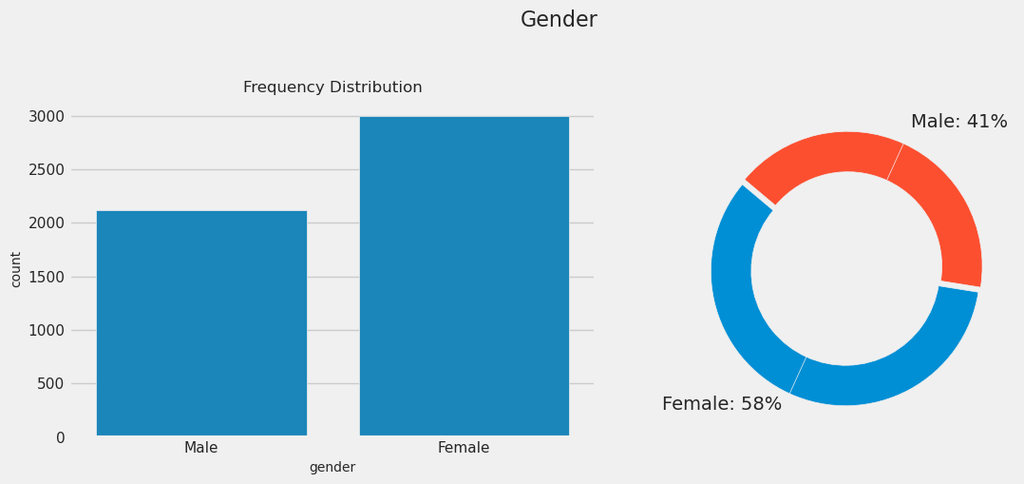

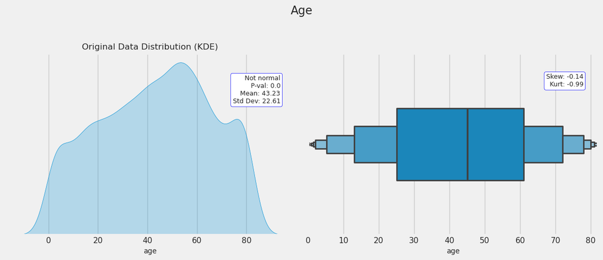

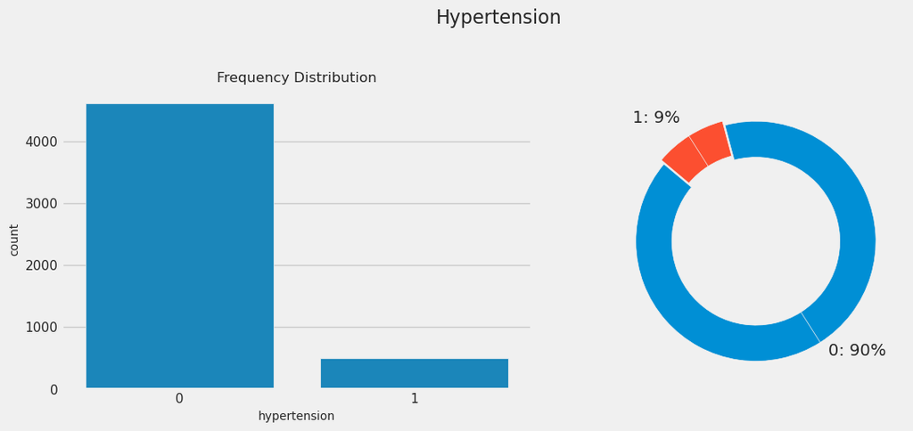

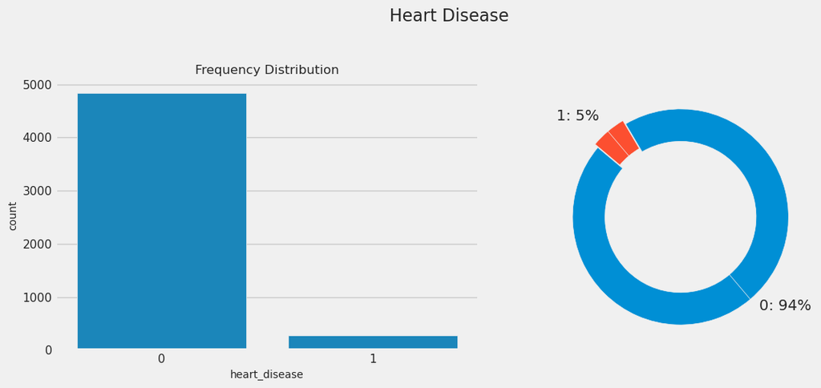

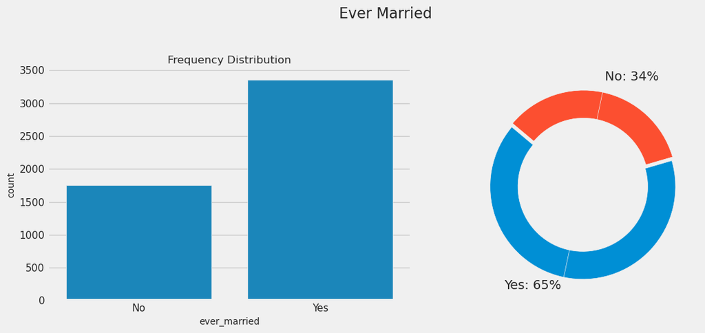

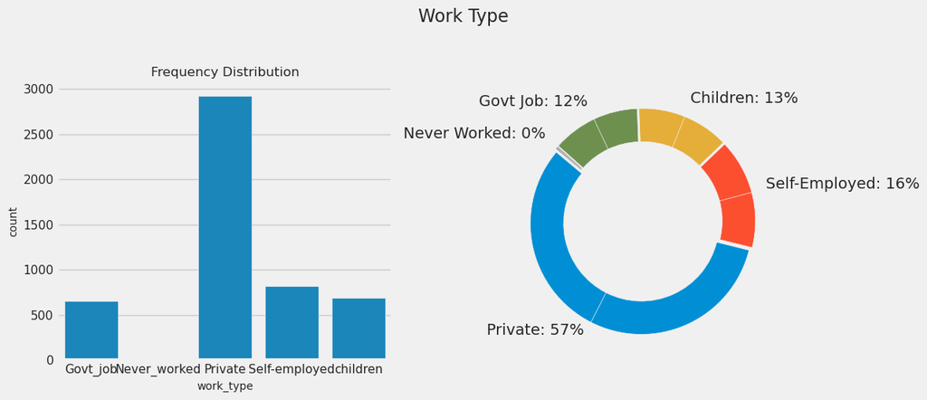

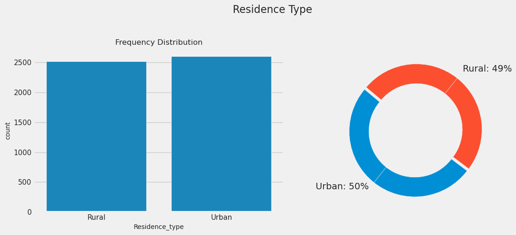

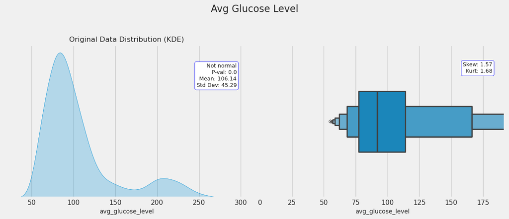

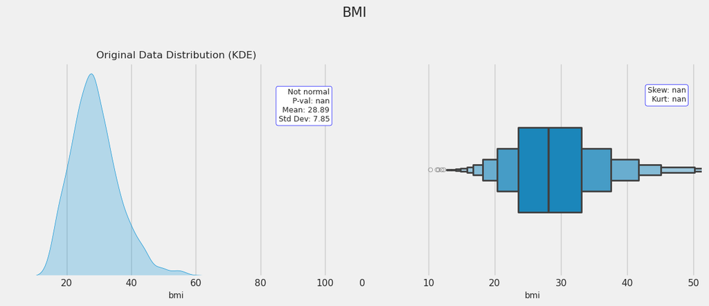

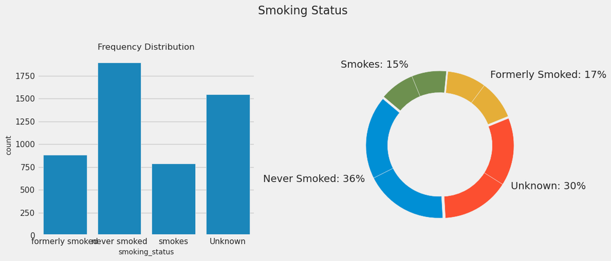

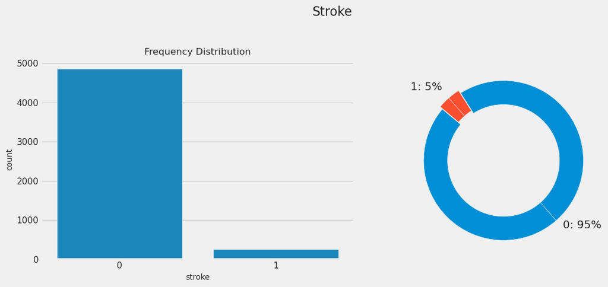

#### 1.2 Relationships between features

[figure not shown]

Because the datatypes of features vary we had to use different methods to measure the strength and significance of each pair:

- Chi-Squared Test: Assesses independence between two categorical variables. For bool-bool pairs due to categorical nature.
- Point Biserial Correlation: Measures correlation between a binary and a continuous variable. For bool-numerical pairs to account for mixed data types.
- Spearman's Rank Correlation: Assesses monotonic relationship between two continuous variables. Used for numerical-numerical pairs (for non-normally distributed data).

Because the Chi-Squared test outputs an unbound statistic/value which can't be directly compared to pointbiserialr or Spearman Rank we have converted them to a `Cramér's V:` value which is normalized between 0 and 1. This was done to make the values in the matrix more uniform however we must note that Cramér's V and Spearman's correlation coefficients are fundamentally different statistics and generally can't be directly compared.

```
smoking_status
never smoked       1892
Unknown            1544
formerly smoked     884
smokes              789
dtype: int64
```

|  | age | hypertension | heart_disease | stroke | smoking_status | high_glucose | overweight | obese |
| --- | --- | --- | --- | --- | --- | --- | --- | --- |
| 0 | 67.0 | 0 | 1 | 1 | False | True | True | True |
| 1 | 61.0 | 0 | 0 | 1 | False | True | False | False |
| 2 | 80.0 | 0 | 1 | 1 | False | False | True | True |
| 3 | 49.0 | 0 | 0 | 1 | True | True | True | True |
| 4 | 79.0 | 1 | 0 | 1 | False | True | False | False |
| ... | ... | ... | ... | ... | ... | ... | ... | ... |
| 5105 | 80.0 | 1 | 0 | 0 | False | False | False | False |
| 5106 | 81.0 | 0 | 0 | 0 | False | True | True | True |
| 5107 | 35.0 | 0 | 0 | 0 | False | False | True | True |
| 5108 | 51.0 | 0 | 0 | 0 | False | True | True | False |
| 5109 | 44.0 | 0 | 0 | 0 | False | False | True | False |

5109 rows × 8 columns

#### Analyzing Risk Factors

We have selected the medical risk factors we would assume might be related to higher stroke risk:

- hypertension
- heart_disease
- high_glucose
- overweight
- obese
- currently smoker

[output not shown]

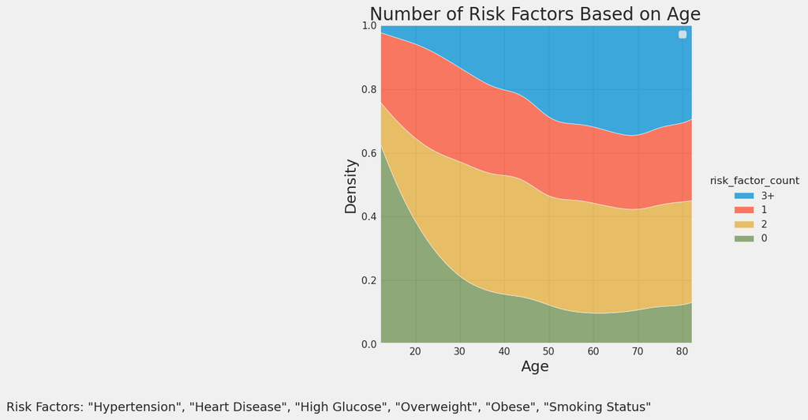

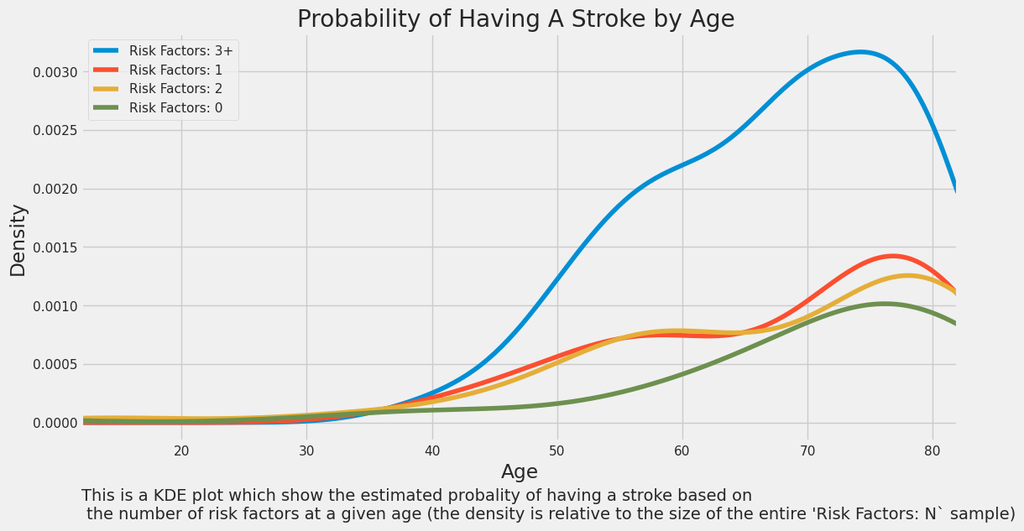

|  | age | hypertension | heart_disease | stroke | smoking_status | high_glucose | overweight | obese | risk_factor_count_raw | risk_factor_count | NO_RISK_FACTORS |
| --- | --- | --- | --- | --- | --- | --- | --- | --- | --- | --- | --- |
| 0 | 67.0 | False | True | True | False | True | True | True | 4.0 | 3+ | False |
| 1 | 61.0 | False | False | True | False | True | False | False | 1.0 | 1 | False |
| 2 | 80.0 | False | True | True | False | False | True | True | 3.0 | 3+ | False |
| 3 | 49.0 | False | False | True | True | True | True | True | 4.0 | 3+ | False |
| 4 | 79.0 | True | False | True | False | True | False | False | 2.0 | 2 | False |
| ... | ... | ... | ... | ... | ... | ... | ... | ... | ... | ... | ... |
| 5105 | 80.0 | True | False | False | False | False | False | False | 1.0 | 1 | False |
| 5106 | 81.0 | False | False | False | False | True | True | True | 3.0 | 3+ | False |
| 5107 | 35.0 | False | False | False | False | False | True | True | 2.0 | 2 | False |
| 5108 | 51.0 | False | False | False | False | True | True | False | 2.0 | 2 | False |
| 5109 | 44.0 | False | False | False | False | False | True | False | 1.0 | 1 | False |

5109 rows × 11 columns

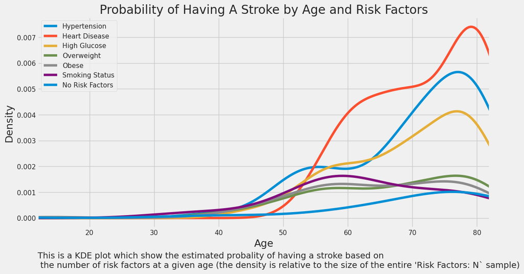

```
[Text(-14.716666666666667, 0.5, '')]
```

[figure not shown]

[output not shown]

[output cut: 314 more lines]

[output not shown]

[output cut: 470 more lines]

|  | hypertension | heart_disease | high_glucose | overweight | obese | smoking_status | stroke | age |
| --- | --- | --- | --- | --- | --- | --- | --- | --- |
| 0 | 0 | 1 | True | True | True | False | 1 | 67.0 |
| 1 | 0 | 0 | True | False | False | False | 1 | 61.0 |
| 2 | 0 | 1 | False | True | True | False | 1 | 80.0 |
| 3 | 0 | 0 | True | True | True | True | 1 | 49.0 |
| 4 | 1 | 0 | True | False | False | False | 1 | 79.0 |
| ... | ... | ... | ... | ... | ... | ... | ... | ... |
| 5105 | 1 | 0 | False | False | False | False | 0 | 80.0 |
| 5106 | 0 | 0 | True | True | True | False | 0 | 81.0 |
| 5107 | 0 | 0 | False | True | True | False | 0 | 35.0 |
| 5108 | 0 | 0 | True | True | False | False | 0 | 51.0 |
| 5109 | 0 | 0 | False | True | False | False | 0 | 44.0 |

5109 rows × 8 columns

|  | age | hypertension | heart_disease | stroke | smoking_status | high_glucose | overweight | obese | risk_factor_count_raw | risk_factor_count |
| --- | --- | --- | --- | --- | --- | --- | --- | --- | --- | --- |
| 0 | 67.0 | 0 | 1 | 1 | False | True | True | True | 4.0 | 3+ |
| 1 | 61.0 | 0 | 0 | 1 | False | True | False | False | 1.0 | 1 |
| 2 | 80.0 | 0 | 1 | 1 | False | False | True | True | 3.0 | 3+ |
| 3 | 49.0 | 0 | 0 | 1 | True | True | True | True | 4.0 | 3+ |
| 4 | 79.0 | 1 | 0 | 1 | False | True | False | False | 2.0 | 2 |
| ... | ... | ... | ... | ... | ... | ... | ... | ... | ... | ... |
| 5105 | 80.0 | 1 | 0 | 0 | False | False | False | False | 1.0 | 1 |
| 5106 | 81.0 | 0 | 0 | 0 | False | True | True | True | 3.0 | 3+ |
| 5107 | 35.0 | 0 | 0 | 0 | False | False | True | True | 2.0 | 2 |
| 5108 | 51.0 | 0 | 0 | 0 | False | True | True | False | 2.0 | 2 |
| 5109 | 44.0 | 0 | 0 | 0 | False | False | True | False | 1.0 | 1 |

5109 rows × 10 columns

This is chart shows individual KDE density curves for each subgroup based on age (it can be interpreted similarly to a histogram).

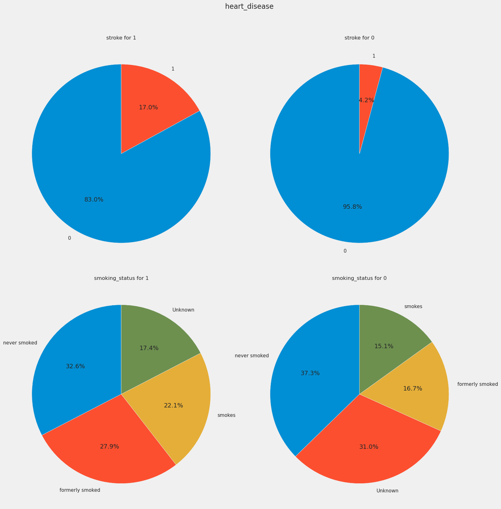

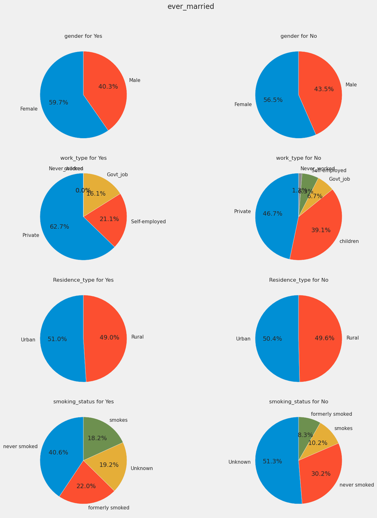

#### Age

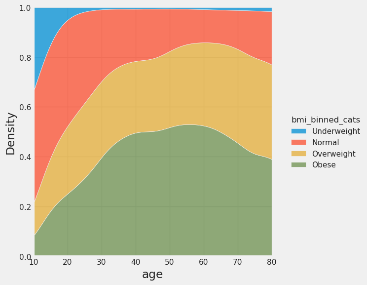

|  | gender | age | hypertension | heart_disease | ever_married | work_type | Residence_type | avg_glucose_level | bmi | smoking_status | stroke | age_binned | avg_glucose_level_binned | bmi_binned | bmi_binned_cats |
| --- | --- | --- | --- | --- | --- | --- | --- | --- | --- | --- | --- | --- | --- | --- | --- |
| 0 | Male | 67.0 | 0 | 1 | Yes | Private | Urban | 228.69 | 36.6 | formerly smoked | 1 | (60, 70] | (125, 999] | (30.0, 999.0] | Obese |
| 1 | Female | 61.0 | 0 | 0 | Yes | Self-employed | Rural | 202.21 | NaN | never smoked | 1 | (60, 70] | (125, 999] | NaN | NaN |
| 2 | Male | 80.0 | 0 | 1 | Yes | Private | Rural | 105.92 | 32.5 | never smoked | 1 | (70, 80] | (100, 125] | (30.0, 999.0] | Obese |
| 3 | Female | 49.0 | 0 | 0 | Yes | Private | Urban | 171.23 | 34.4 | smokes | 1 | (40, 50] | (125, 999] | (30.0, 999.0] | Obese |
| 4 | Female | 79.0 | 1 | 0 | Yes | Self-employed | Rural | 174.12 | 24.0 | never smoked | 1 | (70, 80] | (125, 999] | (18.5, 25.0] | Normal |
| ... | ... | ... | ... | ... | ... | ... | ... | ... | ... | ... | ... | ... | ... | ... | ... |
| 5105 | Female | 80.0 | 1 | 0 | Yes | Private | Urban | 83.75 | NaN | never smoked | 0 | (70, 80] | (80, 100] | NaN | NaN |
| 5106 | Female | 81.0 | 0 | 0 | Yes | Self-employed | Urban | 125.20 | 40.0 | never smoked | 0 | (80, 100] | (125, 999] | (30.0, 999.0] | Obese |
| 5107 | Female | 35.0 | 0 | 0 | Yes | Self-employed | Rural | 82.99 | 30.6 | never smoked | 0 | (30, 40] | (80, 100] | (30.0, 999.0] | Obese |
| 5108 | Male | 51.0 | 0 | 0 | Yes | Private | Rural | 166.29 | 25.6 | formerly smoked | 0 | (50, 60] | (125, 999] | (25.0, 30.0] | Overweight |
| 5109 | Female | 44.0 | 0 | 0 | Yes | Govt_job | Urban | 85.28 | 26.2 | Unknown | 0 | (40, 50] | (80, 100] | (25.0, 30.0] | Overweight |

5109 rows × 15 columns

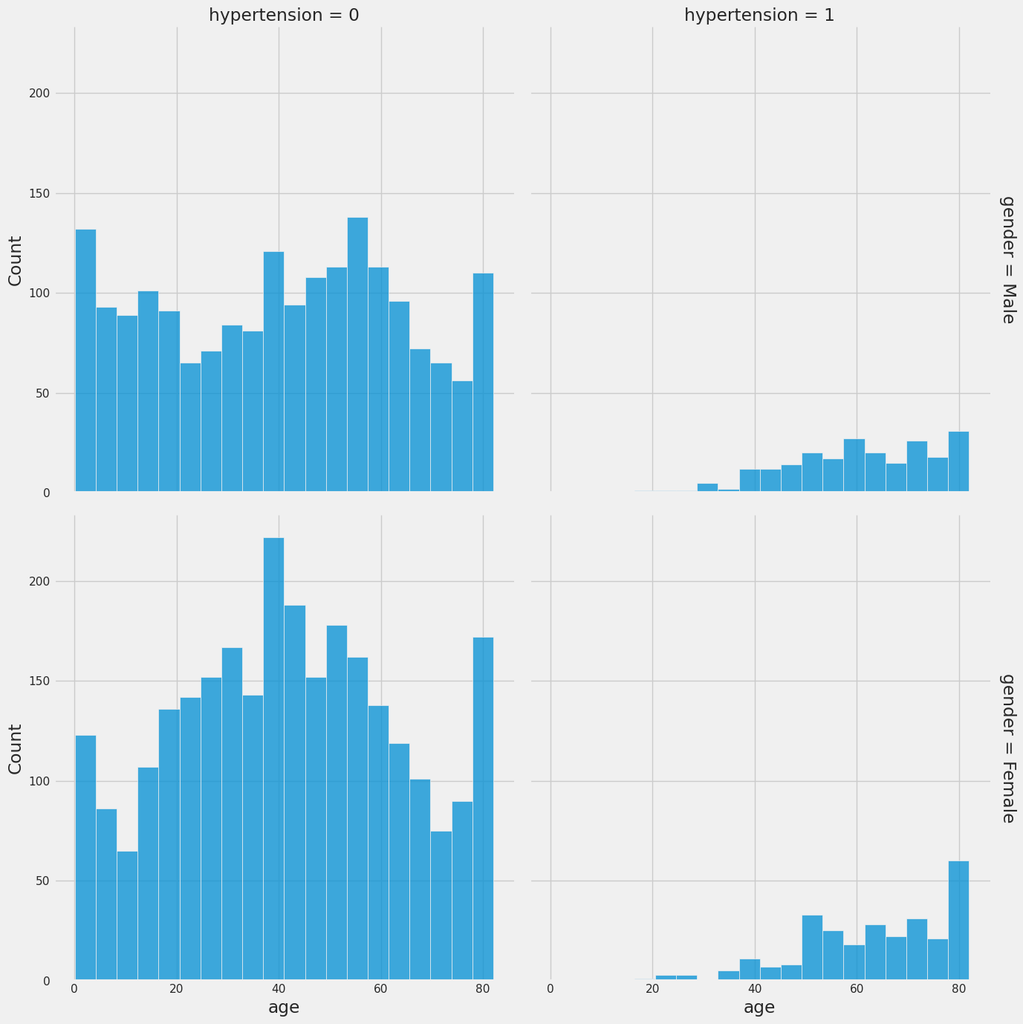

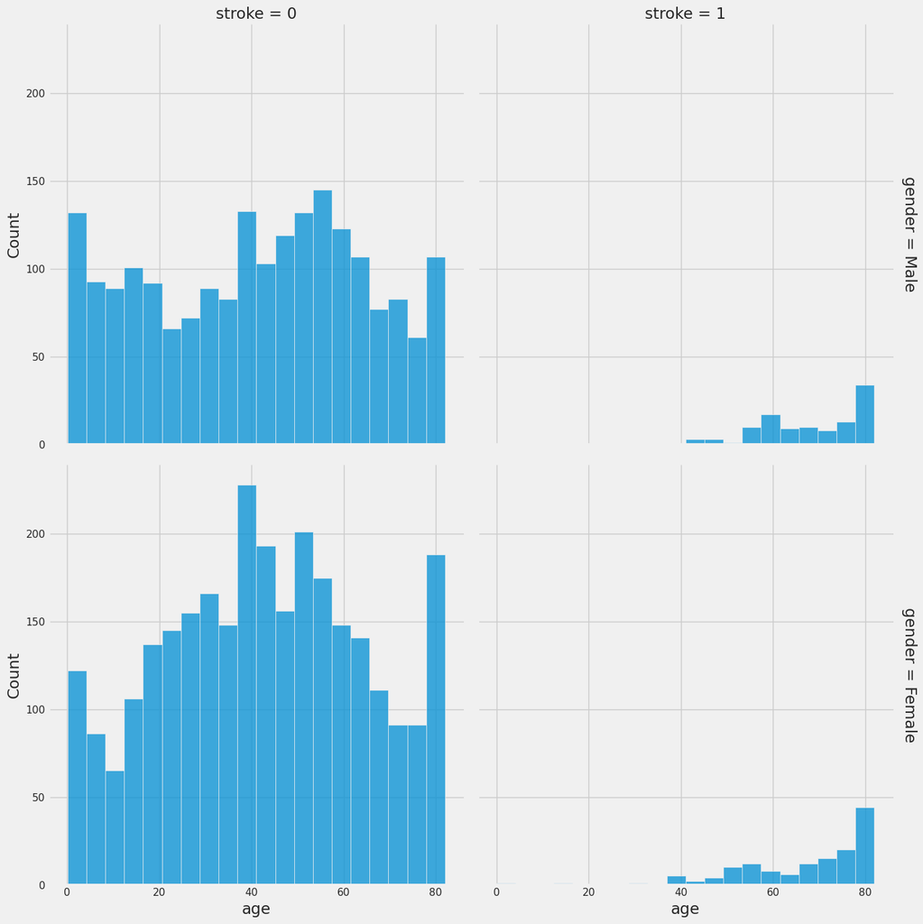

```
gender                        object
age                          float64
hypertension                   int64
heart_disease                  int64
ever_married                category
work_type                   category
Residence_type              category
avg_glucose_level            float64
bmi                          float64
smoking_status                object
stroke                         int64
age_binned                  category
avg_glucose_level_binned    category
bmi_binned                  category
bmi_binned_cats             category
dtype: object
```

#### 1.4 In depth feature analysis

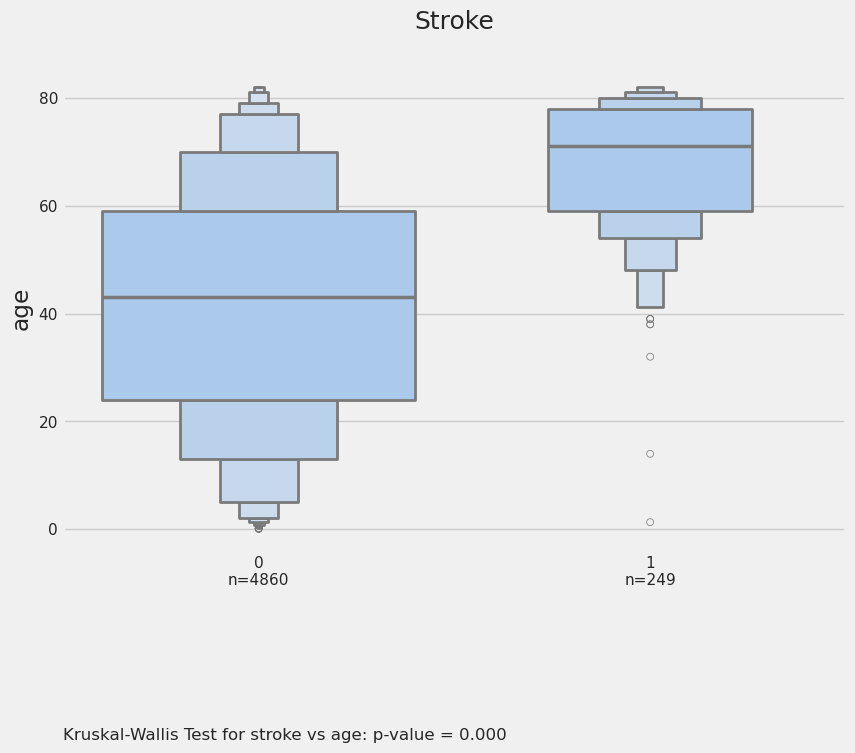

```
gender vs age No significant difference found (p-value = 0.166)
```

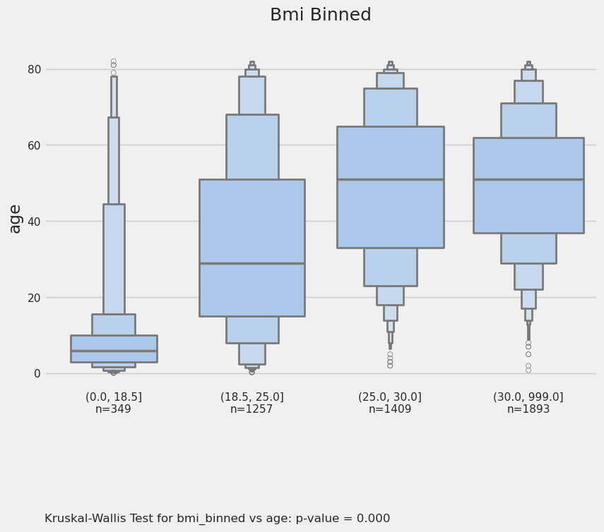

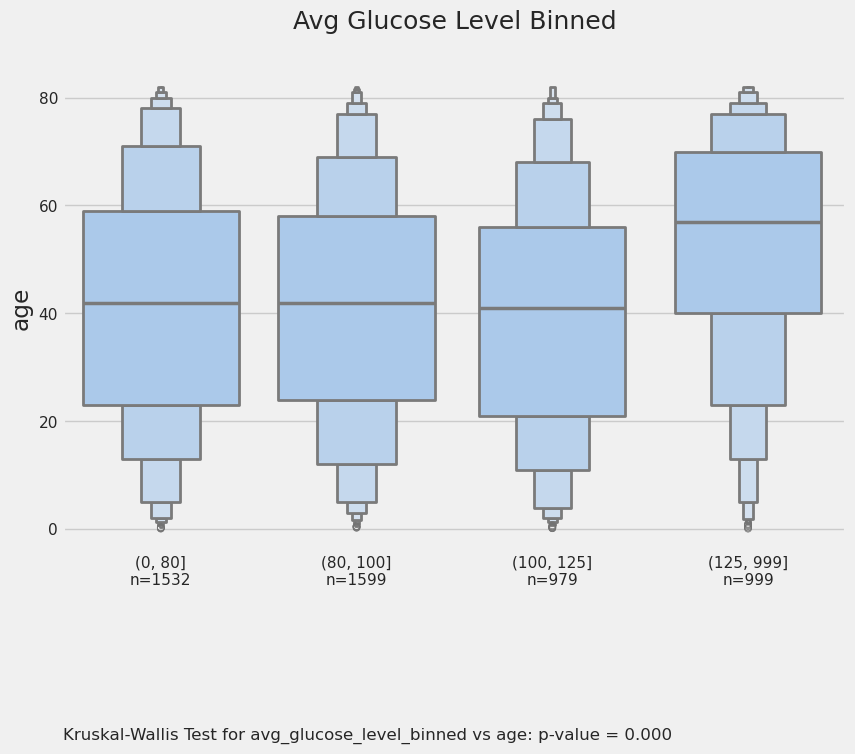

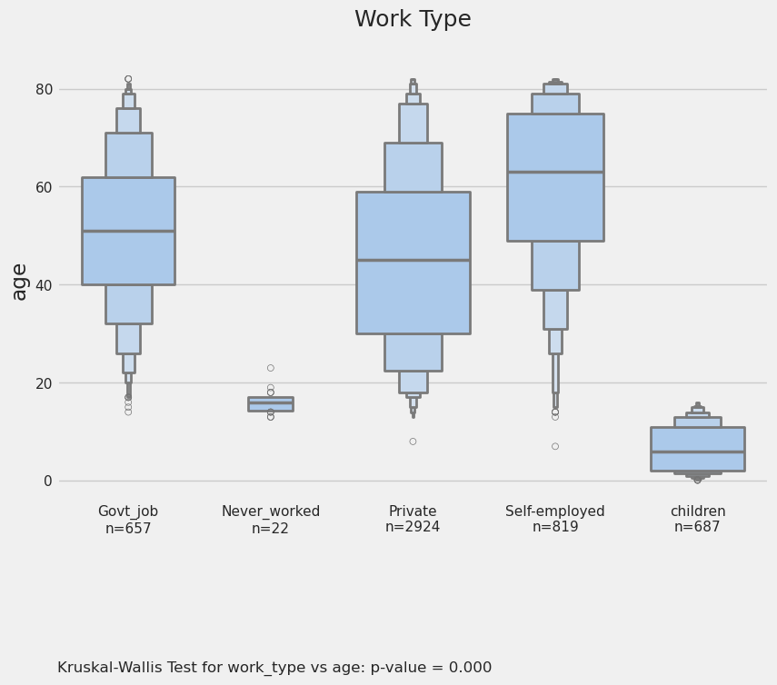

```
Residence_type vs age No significant difference found (p-value = 0.317)
```

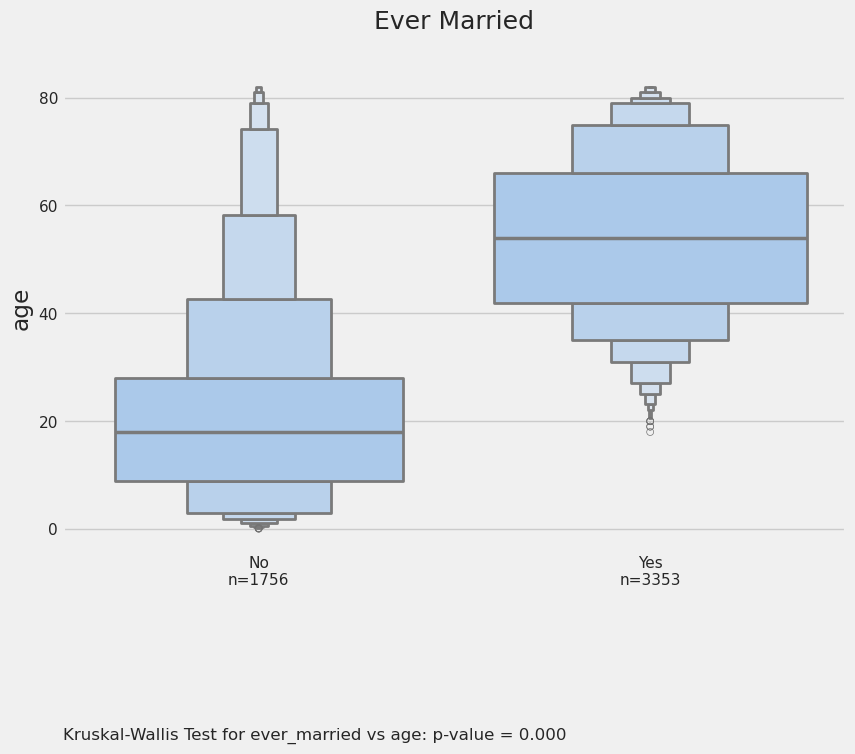

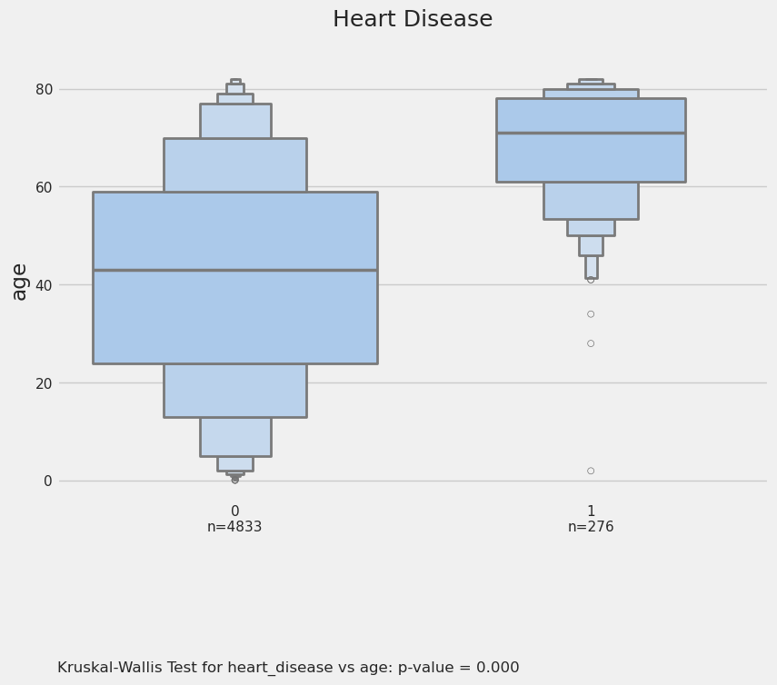

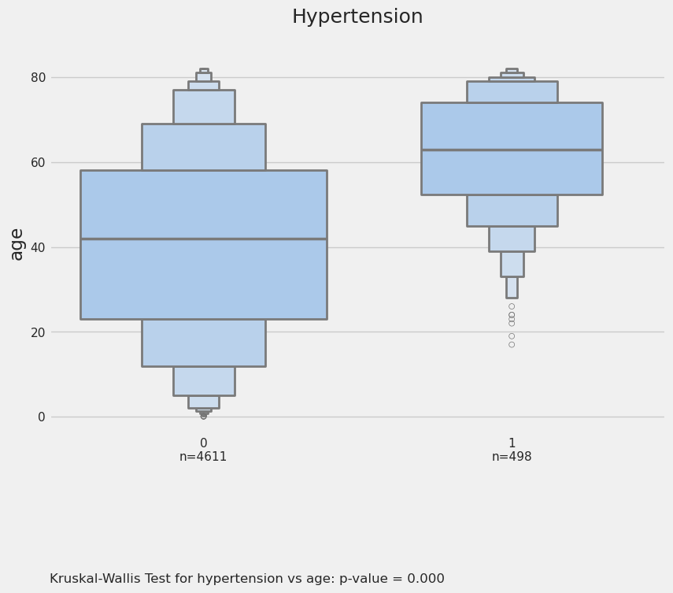

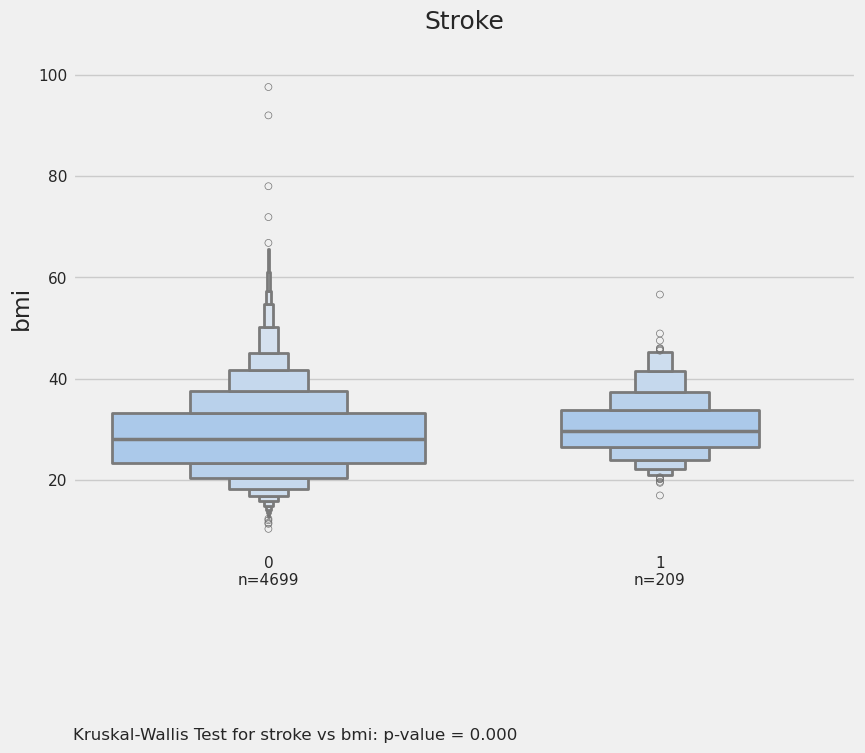

```
gender vs bmi No significant difference found (p-value = 0.982)
```

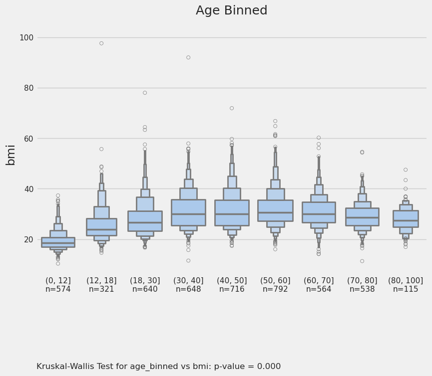

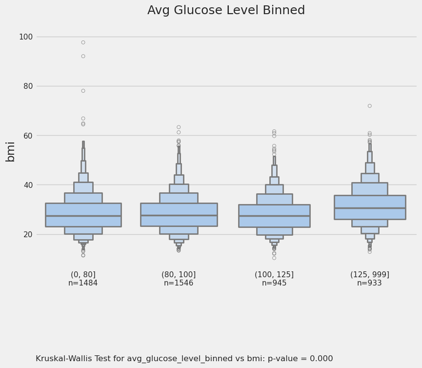

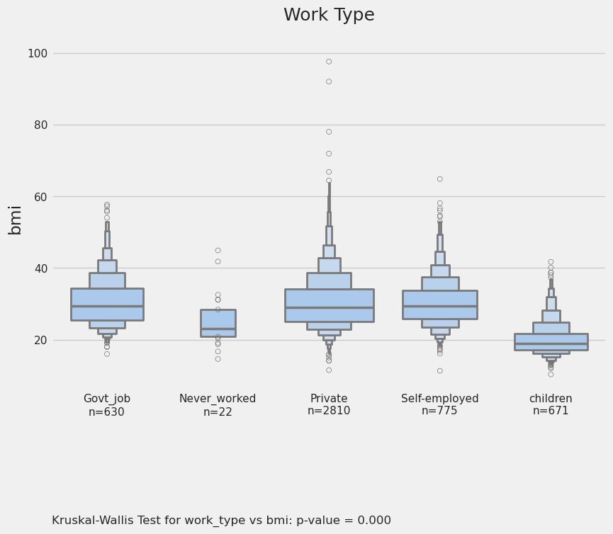